# SmitrajRaut_Personal_Loan_Full_Code_Notebook

| Project Title | Author | Date | GitHub Repository |
| --- | --- | --- | --- |
| **Machine Learning: Personal Loan Campaign** | Smitraj Raut | June 21, 2026 | [Repository Link](https://github.com/Smitraj007/Personal-Loan-Campaign--GL-) |

## Problem Statement

### Context

AllLife Bank is a US bank that has a growing customer base. The majority of these customers are liability customers (depositors) with varying sizes of deposits. The number of customers who are also borrowers (asset customers) is quite small, and the bank is interested in expanding this base rapidly to bring in more loan business and in the process, earn more through the interest on loans. In particular, the management wants to explore ways of converting its liability customers to personal loan customers (while retaining them as depositors).

A campaign that the bank ran last year for liability customers showed a healthy conversion rate of over 9% success. This has encouraged the retail marketing department to devise campaigns with better target marketing to increase the success ratio.

You as a Data scientist at AllLife bank have to build a model that will help the marketing department to identify the potential customers who have a higher probability of purchasing the loan.

### Objective

To predict whether a liability customer will buy personal loans, to understand which customer attributes are most significant in driving purchases, and identify which segment of customers to target more.

### Data Dictionary

- `ID`: Customer ID
- `Age`: Customer’s age in completed years
- `Experience`: #years of professional experience
- `Income`: Annual income of the customer (in thousand dollars)
- `ZIP Code`: Home Address ZIP code.
- `Family`: the Family size of the customer
- `CCAvg`: Average spending on credit cards per month (in thousand dollars)
- `Education`: Education Level. 1: Undergrad; 2: Graduate;3: Advanced/Professional
- `Mortgage`: Value of house mortgage if any. (in thousand dollars)
- `Personal_Loan`: Did this customer accept the personal loan offered in the last campaign? (0: No, 1: Yes)
- `Securities_Account`: Does the customer have securities account with the bank? (0: No, 1: Yes)
- `CD_Account`: Does the customer have a certificate of deposit (CD) account with the bank? (0: No, 1: Yes)
- `Online`: Do customers use internet banking facilities? (0: No, 1: Yes)
- `CreditCard`: Does the customer use a credit card issued by any other Bank (excluding All life Bank)? (0: No, 1: Yes)

### Development Environment

- Local development with Visual Studio Code.
- Jupyter Notebook and Python 3.11.7 with Anaconda3.
- Google Colab/Drive not used.
- Generated HTML using the jupyter cli

  `jupyter nbconvert --to html PYF_Project_LearnerNotebook_FullCode.ipynb`
- Added --- (markdown) lines for easier readability for myself.

### Formatting Notes

- Added line separators for readability.

## Data & Environment Preparation

### Importing necessary libraries

```python
# Installing the libraries with the specified version.
#!pip install numpy==1.25.2 pandas==1.5.3 matplotlib==3.7.1 seaborn==0.13.1 scikit-learn==1.2.2 sklearn-pandas==2.2.0 -q --user

# Visual Studio Code implementation using %pip.
%pip install numpy==1.25.2 pandas==1.5.3 matplotlib==3.7.1 seaborn==0.13.1 scikit-learn==1.2.2 sklearn-pandas==2.2.0 -q --user
```

```python
# Libraries to help with reading and manipulating data.
import pandas as pd
import numpy as np

# libaries to help with data visualization.
import matplotlib.pyplot as plt
import seaborn as sns

# Libraries to help with data preprocessing.
import matplotlib.patches as mpatches
from matplotlib.ticker import FuncFormatter

# Removes the limit for the number of displayed columns.
pd.set_option("display.max_columns", None)
# Sets the limit for the number of displayed rows.
pd.set_option("display.max_rows", 200)

# Library to split data.
from sklearn.model_selection import train_test_split

# To build model for prediction.
from sklearn.tree import DecisionTreeClassifier
from sklearn import tree

# To tune different models.
from sklearn.model_selection import GridSearchCV

# To get diferent metric scores.
from sklearn.metrics import (
    f1_score,
    accuracy_score,
    recall_score,
    precision_score,
    confusion_matrix,
    make_scorer,
    classification_report,
)

# Suppress warnings (FutureWarning).
import warnings
warnings.filterwarnings("ignore", category= FutureWarning)
```

### Loading the dataset

```python
# Read the dataset from the Loan_Modelling.csv file locally. Pandas DataFrame object
# assigned to personal_loan_df.
personal_load_df_original = pd.read_csv("/Users/smitraj/Desktop/Personal-Loan-Campaign/Loan_Modelling.csv")

# Create a copy of the original DataFrame to avoid modifying the original data.
personal_loan_df = personal_load_df_original.copy()
```

## Understanding the Structure of the Data

**Note:** All observations are summarized at the bottomn of the Data Overview section.

### Data Overview

- Observations
- Sanity checks

```python
# Retrieve first 5 rows of the dataset.
print('First 5 rows of the dataset:')
print(personal_loan_df.head(5).to_string(index=False))

print()

# Retrieve last 5 rows of the dataset.
print('Last 5 rows of the dataset:')
print(personal_loan_df.tail(5).to_string(index=False))
```

```
First 5 rows of the dataset:
 ID  Age  Experience  Income  ZIPCode  Family  CCAvg  Education  Mortgage  Personal_Loan  Securities_Account  CD_Account  Online  CreditCard
  1   25           1      49    91107       4    1.6          1         0              0                   1           0       0           0
  2   45          19      34    90089       3    1.5          1         0              0                   1           0       0           0
  3   39          15      11    94720       1    1.0          1         0              0                   0           0       0           0
  4   35           9     100    94112       1    2.7          2         0              0                   0           0       0           0
  5   35           8      45    91330       4    1.0          2         0              0                   0           0       0           1

Last 5 rows of the dataset:
  ID  Age  Experience  Income  ZIPCode  Family  CCAvg  Education  Mortgage  Personal_Loan  Securities_Account  CD_Account  Online  CreditCard
4996   29           3      40    92697       1    1.9          3         0              0                   0           0       1           0
4997   30           4      15    92037       4    0.4          1        85              0                   0           0       1           0
4998   63          39      24    93023       2    0.3          3         0              0                   0           0       0           0
4999   65          40      49    90034       3    0.5          2         0              0                   0           0       1           0
5000   28           4      83    92612       3    0.8          1         0              0                   0           0       1           1
```

```python
# Number of rows and columns in the data using the shape attribute of the DataFrame.
rows, columns = personal_loan_df.shape

# Print the number of rows and columns from the dataset. Output is formatted into thousands.
# There are only 9 columns but for consistency, the output includes (,) format.
print(f'Number of Rows: {rows:,}')
print(f'Number of Columns: {columns:,}')
```

```
Number of Rows: 5,000
Number of Columns: 14
```

```python
# Retrieve summary information of the DataFrame using the info() method.
personal_loan_df.info()
```

```
<class 'pandas.core.frame.DataFrame'>
RangeIndex: 5000 entries, 0 to 4999
Data columns (total 14 columns):
 #   Column              Non-Null Count  Dtype
---  ------              --------------  -----
 0   ID                  5000 non-null   int64
 1   Age                 5000 non-null   int64
 2   Experience          5000 non-null   int64
 3   Income              5000 non-null   int64
 4   ZIPCode             5000 non-null   int64
 5   Family              5000 non-null   int64
 6   CCAvg               5000 non-null   float64
 7   Education           5000 non-null   int64
 8   Mortgage            5000 non-null   int64
 9   Personal_Loan       5000 non-null   int64
 10  Securities_Account  5000 non-null   int64
 11  CD_Account          5000 non-null   int64
 12  Online              5000 non-null   int64
 13  CreditCard          5000 non-null   int64
dtypes: float64(1), int64(13)
memory usage: 547.0 KB
```

```python
# Determine if there is any missing data.
missing_values = personal_loan_df.isnull().sum()

# Check for nulls and NaN values in the dataset.
print('Null values ' + str(personal_loan_df.isnull().sum()) + '\n')
print('NaN values ' + str(personal_loan_df.isna().sum()) + '\n')

# Output if there are any missing data points in the dataset.
if missing_values.sum() > 0:
    print('There are missing data points in the Personal Loan dataset.')
else:
    print('There are no missing data points in the Personal Load dataset.')
```

```
Null values ID                    0
Age                   0
Experience            0
Income                0
ZIPCode               0
Family                0
CCAvg                 0
Education             0
Mortgage              0
Personal_Loan         0
Securities_Account    0
CD_Account            0
Online                0
CreditCard            0
dtype: int64

NaN values ID                    0
Age                   0
Experience            0
Income                0
ZIPCode               0
Family                0
CCAvg                 0
Education             0
Mortgage              0
Personal_Loan         0
Securities_Account    0
CD_Account            0
Online                0
CreditCard            0
dtype: int64

There are no missing data points in the Personal Load dataset.
```

```python
# Retrieve full statistics of the dataset.
personal_loan_df.describe()
```

|  | ID | Age | Experience | Income | ZIPCode | Family | CCAvg | Education | Mortgage | Personal_Loan | Securities_Account | CD_Account | Online | CreditCard |
| --- | --- | --- | --- | --- | --- | --- | --- | --- | --- | --- | --- | --- | --- | --- |
| count | 5000.000000 | 5000.000000 | 5000.000000 | 5000.000000 | 5000.000000 | 5000.000000 | 5000.000000 | 5000.000000 | 5000.000000 | 5000.000000 | 5000.000000 | 5000.00000 | 5000.000000 | 5000.000000 |
| mean | 2500.500000 | 45.338400 | 20.104600 | 73.774200 | 93169.257000 | 2.396400 | 1.937938 | 1.881000 | 56.498800 | 0.096000 | 0.104400 | 0.06040 | 0.596800 | 0.294000 |
| std | 1443.520003 | 11.463166 | 11.467954 | 46.033729 | 1759.455086 | 1.147663 | 1.747659 | 0.839869 | 101.713802 | 0.294621 | 0.305809 | 0.23825 | 0.490589 | 0.455637 |
| min | 1.000000 | 23.000000 | -3.000000 | 8.000000 | 90005.000000 | 1.000000 | 0.000000 | 1.000000 | 0.000000 | 0.000000 | 0.000000 | 0.00000 | 0.000000 | 0.000000 |
| 25% | 1250.750000 | 35.000000 | 10.000000 | 39.000000 | 91911.000000 | 1.000000 | 0.700000 | 1.000000 | 0.000000 | 0.000000 | 0.000000 | 0.00000 | 0.000000 | 0.000000 |
| 50% | 2500.500000 | 45.000000 | 20.000000 | 64.000000 | 93437.000000 | 2.000000 | 1.500000 | 2.000000 | 0.000000 | 0.000000 | 0.000000 | 0.00000 | 1.000000 | 0.000000 |
| 75% | 3750.250000 | 55.000000 | 30.000000 | 98.000000 | 94608.000000 | 3.000000 | 2.500000 | 3.000000 | 101.000000 | 0.000000 | 0.000000 | 0.00000 | 1.000000 | 1.000000 |
| max | 5000.000000 | 67.000000 | 43.000000 | 224.000000 | 96651.000000 | 4.000000 | 10.000000 | 3.000000 | 635.000000 | 1.000000 | 1.000000 | 1.00000 | 1.000000 | 1.000000 |

```python
# Using the describe() function with (include-'all').T can make the data more readable.
personal_loan_df.describe(include='all').T
```

|  | count | mean | std | min | 25% | 50% | 75% | max |
| --- | --- | --- | --- | --- | --- | --- | --- | --- |
| ID | 5000.0 | 2500.500000 | 1443.520003 | 1.0 | 1250.75 | 2500.5 | 3750.25 | 5000.0 |
| Age | 5000.0 | 45.338400 | 11.463166 | 23.0 | 35.00 | 45.0 | 55.00 | 67.0 |
| Experience | 5000.0 | 20.104600 | 11.467954 | -3.0 | 10.00 | 20.0 | 30.00 | 43.0 |
| Income | 5000.0 | 73.774200 | 46.033729 | 8.0 | 39.00 | 64.0 | 98.00 | 224.0 |
| ZIPCode | 5000.0 | 93169.257000 | 1759.455086 | 90005.0 | 91911.00 | 93437.0 | 94608.00 | 96651.0 |
| Family | 5000.0 | 2.396400 | 1.147663 | 1.0 | 1.00 | 2.0 | 3.00 | 4.0 |
| CCAvg | 5000.0 | 1.937938 | 1.747659 | 0.0 | 0.70 | 1.5 | 2.50 | 10.0 |
| Education | 5000.0 | 1.881000 | 0.839869 | 1.0 | 1.00 | 2.0 | 3.00 | 3.0 |
| Mortgage | 5000.0 | 56.498800 | 101.713802 | 0.0 | 0.00 | 0.0 | 101.00 | 635.0 |
| Personal_Loan | 5000.0 | 0.096000 | 0.294621 | 0.0 | 0.00 | 0.0 | 0.00 | 1.0 |
| Securities_Account | 5000.0 | 0.104400 | 0.305809 | 0.0 | 0.00 | 0.0 | 0.00 | 1.0 |
| CD_Account | 5000.0 | 0.060400 | 0.238250 | 0.0 | 0.00 | 0.0 | 0.00 | 1.0 |
| Online | 5000.0 | 0.596800 | 0.490589 | 0.0 | 0.00 | 1.0 | 1.00 | 1.0 |
| CreditCard | 5000.0 | 0.294000 | 0.455637 | 0.0 | 0.00 | 0.0 | 1.00 | 1.0 |

```python
# Drop the ID column from the dataset.
if 'ID' in personal_loan_df.columns:
    personal_loan_df.drop(['ID'], axis=1, inplace=True)

# Retrieve the first 5 rows of the dataset after dropping the ID column.
print('First 5 rows of the dataset after dropping the ID column:')
print(personal_loan_df.head(5).to_string(index=False))
```

```
First 5 rows of the dataset after dropping the ID column:
 Age  Experience  Income  ZIPCode  Family  CCAvg  Education  Mortgage  Personal_Loan  Securities_Account  CD_Account  Online  CreditCard
  25           1      49    91107       4    1.6          1         0              0                   1           0       0           0
  45          19      34    90089       3    1.5          1         0              0                   1           0       0           0
  39          15      11    94720       1    1.0          1         0              0                   0           0       0           0
  35           9     100    94112       1    2.7          2         0              0                   0           0       0           0
  35           8      45    91330       4    1.0          2         0              0                   0           0       0           1
```

```python
# Find correlation between the variables in the dataset.
personal_loan_df.corr()
```

|  | Age | Experience | Income | ZIPCode | Family | CCAvg | Education | Mortgage | Personal_Loan | Securities_Account | CD_Account | Online | CreditCard |
| --- | --- | --- | --- | --- | --- | --- | --- | --- | --- | --- | --- | --- | --- |
| Age | 1.000000 | 0.994215 | -0.055269 | -0.030530 | -0.046418 | -0.052012 | 0.041334 | -0.012539 | -0.007726 | -0.000436 | 0.008043 | 0.013702 | 0.007681 |
| Experience | 0.994215 | 1.000000 | -0.046574 | -0.030456 | -0.052563 | -0.050077 | 0.013152 | -0.010582 | -0.007413 | -0.001232 | 0.010353 | 0.013898 | 0.008967 |
| Income | -0.055269 | -0.046574 | 1.000000 | -0.030709 | -0.157501 | 0.645984 | -0.187524 | 0.206806 | 0.502462 | -0.002616 | 0.169738 | 0.014206 | -0.002385 |
| ZIPCode | -0.030530 | -0.030456 | -0.030709 | 1.000000 | 0.027512 | -0.012188 | -0.008266 | 0.003614 | -0.002974 | 0.002422 | 0.021671 | 0.028317 | 0.024033 |
| Family | -0.046418 | -0.052563 | -0.157501 | 0.027512 | 1.000000 | -0.109275 | 0.064929 | -0.020445 | 0.061367 | 0.019994 | 0.014110 | 0.010354 | 0.011588 |
| CCAvg | -0.052012 | -0.050077 | 0.645984 | -0.012188 | -0.109275 | 1.000000 | -0.136124 | 0.109905 | 0.366889 | 0.015086 | 0.136534 | -0.003611 | -0.006689 |
| Education | 0.041334 | 0.013152 | -0.187524 | -0.008266 | 0.064929 | -0.136124 | 1.000000 | -0.033327 | 0.136722 | -0.010812 | 0.013934 | -0.015004 | -0.011014 |
| Mortgage | -0.012539 | -0.010582 | 0.206806 | 0.003614 | -0.020445 | 0.109905 | -0.033327 | 1.000000 | 0.142095 | -0.005411 | 0.089311 | -0.005995 | -0.007231 |
| Personal_Loan | -0.007726 | -0.007413 | 0.502462 | -0.002974 | 0.061367 | 0.366889 | 0.136722 | 0.142095 | 1.000000 | 0.021954 | 0.316355 | 0.006278 | 0.002802 |
| Securities_Account | -0.000436 | -0.001232 | -0.002616 | 0.002422 | 0.019994 | 0.015086 | -0.010812 | -0.005411 | 0.021954 | 1.000000 | 0.317034 | 0.012627 | -0.015028 |
| CD_Account | 0.008043 | 0.010353 | 0.169738 | 0.021671 | 0.014110 | 0.136534 | 0.013934 | 0.089311 | 0.316355 | 0.317034 | 1.000000 | 0.175880 | 0.278644 |
| Online | 0.013702 | 0.013898 | 0.014206 | 0.028317 | 0.010354 | -0.003611 | -0.015004 | -0.005995 | 0.006278 | 0.012627 | 0.175880 | 1.000000 | 0.004210 |
| CreditCard | 0.007681 | 0.008967 | -0.002385 | 0.024033 | 0.011588 | -0.006689 | -0.011014 | -0.007231 | 0.002802 | -0.015028 | 0.278644 | 0.004210 | 1.000000 |

```python
# Calculate the distribution of mortgages.
mortgage_distribution = personal_loan_df['Mortgage'].value_counts()

# Sort the distribution in descending order.
mortgage_distribution_sorted = mortgage_distribution.sort_values(ascending=False)

# Format the mortgage values into dollars.
mortgage_distribution_sorted.index = mortgage_distribution_sorted.index.map(lambda x: f'${x:,.0f}K')

# Print the distribution of mortgages.
print('Distribution of Mortgages (descending order):')
print(mortgage_distribution_sorted)
```

```
Distribution of Mortgages (descending order):
$0K      3462
$98K       17
$119K      16
$91K       16
$103K      16
         ...
$281K       1
$577K       1
$302K       1
$405K       1
$541K       1
Name: Mortgage, Length: 347, dtype: int64
```

```python
# Create a cross-tabulation of ZIP code and Education.
zip_education_crosstab = pd.crosstab(personal_loan_df['ZIPCode'], personal_loan_df['Education'])

# Filter rows where education level count is greater than 20.
zipcode_education_sorted = zip_education_crosstab[zip_education_crosstab > 20].dropna(how='all')

# Print the cross-tabulation of ZIP code and Education.
print('Cross-tabulation of ZIP code and Education:')
print(zipcode_education_sorted.to_string())
```

```
Cross-tabulation of ZIP code and Education:
Education     1     2     3
ZIPCode
90089      22.0   NaN   NaN
90095      25.0   NaN  26.0
90245       NaN   NaN  21.0
91320      22.0   NaN   NaN
92037      25.0   NaN   NaN
92121      25.0   NaN   NaN
93106       NaN   NaN  22.0
93943      28.0   NaN   NaN
94025       NaN   NaN  22.0
94305      51.0  40.0  36.0
94720      68.0  49.0  52.0
95616      47.0  36.0  33.0
```

```python
# Check for zero or negative values in columns.
columns_to_check = ['Income', 'CCAvg', 'Mortgage','Securities_Account', 'CD_Account', 'Online', 'CreditCard']
for column in columns_to_check:
    invalid_values = personal_loan_df[personal_loan_df[column] <= 0]
    print(f'Number of rows with non-positive values in {column}: {len(invalid_values)}')
```

```
Number of rows with non-positive values in Income: 0
Number of rows with non-positive values in CCAvg: 106
Number of rows with non-positive values in Mortgage: 3462
Number of rows with non-positive values in Securities_Account: 4478
Number of rows with non-positive values in CD_Account: 4698
Number of rows with non-positive values in Online: 2016
Number of rows with non-positive values in CreditCard: 3530
```

```python
# Checking to see if there is a correlation between Education level and Mortgage amount.
# Calculate the correlation between 'Mortgage' and 'Education'
correlation = personal_loan_df['Mortgage'].corr(personal_loan_df['Education'])

print(f"The correlation between Mortgage and Education is: {correlation}")
```

```
The correlation between Mortgage and Education is: -0.03332712462995044
```

### Observations

**General Data Observations**

**Feature Observations**

- The strong correlation between Income and CCAvg indicates that both features are important and should be considered in models related to financial behavior.
- The moderate correlations between Income and both Personal_Loan and CCAvg suggest that high-income individuals are good targets for personal loan offers and credit card promotions
- The correlation between Securities_Account and CD_Account suggests that individuals with one type of financial product are more likely to have the other. Financial institutions could consider bundling these products in their marketing strategies.

**ZIP Code Observations**

- The most common ZIP code is 94720 with 169 occurrences, followed by 94305 with 127 occurrences, and 95616 with 116 occurrences. These ZIP codes represent the areas with the highest concentration of individuals in the dataset.
- The top 20 ZIP codes have frequencies ranging from 169 to 34. This indicates that there are several areas with a relatively high number of individuals.
- The high frequencies of certain ZIP codes suggest a concentration of individuals in specific geographical areas. For example, ZIP codes 94720, 94305, and 95616 are likely to be significant regions in the dataset. Potential Regional Bias:
- The dataset appears to have a regional bias towards certain ZIP codes. This could be due to the sampling method or the nature of the data collection. It is important to consider this bias when making generalizations or building models.
- While there is a concentration in the top ZIP codes, the presence of 20 different ZIP codes in the top frequencies indicates a diverse representation of geographical areas.
- ZIP Code 94720 has 169 occurrences, this ZIP code has the highest representation. This could be a key area for targeted marketing or further analysis.

**Mortgage Observations**

- The most common mortgage amount is $0K, with 3,462 occurrences. This indicates that a significant portion of individuals in the dataset do not have a mortgage. Distribution of Non-Zero Mortgages:
- The frequencies of non-zero mortgage amounts are significantly lower compared to zero mortgages. The highest frequency among non-zero mortgages is $98K with 17 occurrences, followed by $119K, $91K, and $103K, each with 16 occurrences.
- There is a long tail of mortgage amounts with very low frequencies. Many mortgage amounts (e.g., $281K, $577K, $302K, $405K, $541K) have only 1 occurrence each. This indicates a wide range of mortgage amounts with sparse representation.
- The distribution is heavily skewed towards zero mortgages, with a rapid drop-off in frequency as the mortgage amounts increase. This suggests that most individuals either have no mortgage or relatively low mortgage amounts.
- Education and Mortgage has a -0.0333 which shows no linear relationship between them.

## Exploratory Data Analysis

- EDA is an important part of any project involving data.
- It is important to investigate and understand the data better before building a model with it.
- A few questions have been mentioned below which will help you approach the analysis in the right manner and generate insights from the data.
- A thorough analysis of the data, in addition to the questions mentioned below, should be done.

**Questions**:

1. What is the distribution of mortgage attribute? Are there any noticeable patterns or outliers in the distribution?
2. How many customers have credit cards?
3. What are the attributes that have a strong correlation with the target attribute (personal loan)?
4. How does a customer's interest in purchasing a loan vary with their age?
5. How does a customer's interest in purchasing a loan vary with their education?

**Additional Questions**:

6. What is the distribution of mortgages for customers with and without credit cards?
7. Does average spending on credit cards per month impact mortgage amount?
8. Does income impact mortgage amount?
9. Does income reflect higher or lower average credit card spending?
10. What are all of the distributions?
11. What is the relationship between Online Banking Usage vs Education?
12. What is the relationship between Personal Loan vs Education?
13. What is the relationship between Online Banking Usage vs Top 10 ZIP Codes?
14. What is the relationship between having a CD Account vs Education?
15. What is the relationship between having a Average Credit Card spending vs Education?
16. What is the relationship between having a Average Credit Card spending vs Mortgage?
17. What are the relationships between Predictor and Target?

#### **Question 1.** What is the distribution of mortgage attribute? Are there any noticeable patterns or outliers in the distribution?

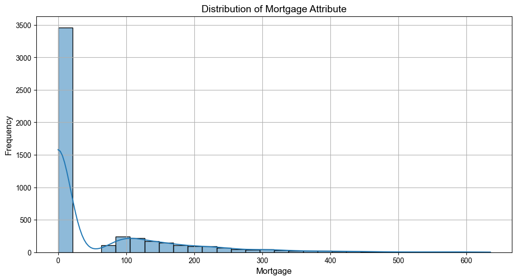

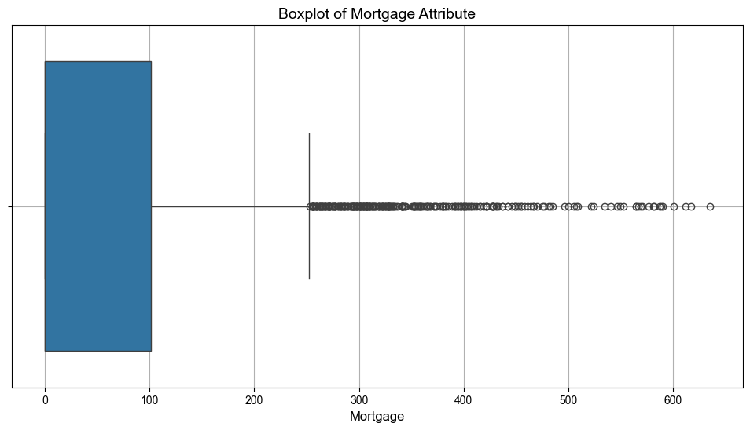

```python
# Plot the distribution of mortgage using a histogram.
plt.figure(figsize=(12, 6))
sns.histplot(personal_loan_df['Mortgage'], bins=30, kde=True)
plt.title('Distribution of Mortgage Attribute')
plt.xlabel('Mortgage')
plt.ylabel('Frequency')
plt.grid(True)
plt.show()

# Plot the distribution of mortgage using a boxplot to identify outliers.
plt.figure(figsize=(12, 6))
sns.boxplot(x=personal_loan_df['Mortgage'])
plt.title('Boxplot of Mortgage Attribute')
plt.xlabel('Mortgage')
plt.grid(True)
plt.show()
```

```python
# Number of customers with no mortgage.
no_mortgage_count = personal_loan_df[personal_loan_df['Mortgage'] == 0].shape[0]

# Total number of customers.
total_customers = personal_loan_df.shape[0]

# Percentage of customers with no mortgage.
percentage_no_mortgage = (no_mortgage_count / total_customers) * 100

print(f"Number of customers with no mortgage: {no_mortgage_count:,}")
print(f"Total number of customers: {total_customers:,}")
print(f'Percentage of customers with no mortgage: {percentage_no_mortgage:.2f}%')
```

```
Number of customers with no mortgage: 3,462
Total number of customers: 5,000
Percentage of customers with no mortgage: 69.24%
```

**Observations**

- 69.24% of customers do not have a mortgage ($0). This is a significant number within the overall customer base.
  - **Recommendation:** Market to these customers with a special program with low introductory rates to capture business.

#### **Question 2.** How many customers have credit cards?

```python
# Total number of customers.
total_customers = personal_loan_df.shape[0]

# Number of customers with credit cards from All Life Bank and other banks.
other_cc = personal_loan_df[personal_loan_df['CreditCard'] == 1].shape[0]
all_life_bank_cc = personal_loan_df[personal_loan_df['CreditCard'] == 0].shape[0]

print(f'Number of customers with All Life Bank credit card: {all_life_bank_cc:,}')
print(f'Number of customers using a credit card at another bank: {other_cc:,}')
print(f'Total number of customers: {total_customers:,}')
print(f'Percentage of customers with credit cards: {(other_cc / total_customers * 100):.2f}%')
```

```
Number of customers with All Life Bank credit card: 3,530
Number of customers using a credit card at another bank: 1,470
Total number of customers: 5,000
Percentage of customers with credit cards: 29.40%
```

**Observations**

- 29.4% of customers have credit cards from other banks.
  - **Recommendation:** Market a special program with low introductory APR to capture business away from competitors.

#### **Question 3.** What are the attributes that have a strong correlation with the target attribute (personal loan)?

```python
# Find the highest correlated feature pairs in the personal_loan_df DataFrame.
correlation_matrix = personal_loan_df.corr(numeric_only=True)

# Unstack the correlation matrix.
correlation_pairs = correlation_matrix.unstack()

# Filter out self-correlations.
filtered_pairs = correlation_pairs[correlation_pairs != 1]

# Sort the correlations in descending order.
sorted_pairs = filtered_pairs.sort_values(ascending=False)

# Display the correlated feature pairs.
highest_correlated_features = sorted_pairs.head(10)
print(highest_correlated_features)
```

```
Age                 Experience            0.994215
Experience          Age                   0.994215
CCAvg               Income                0.645984
Income              CCAvg                 0.645984
                    Personal_Loan         0.502462
Personal_Loan       Income                0.502462
CCAvg               Personal_Loan         0.366889
Personal_Loan       CCAvg                 0.366889
Securities_Account  CD_Account            0.317034
CD_Account          Securities_Account    0.317034
dtype: float64
```

```python
# Calculate the correlation matrix.
correlation_matrix = personal_loan_df.corr(numeric_only=True)

# Get correlations with the target attribute (Personal Loan).
correlations_with_target = correlation_matrix['Personal_Loan'].drop('Personal_Loan')

# Identify attributes with strong correlations (absolute value > 0.5)
strong_correlations = correlations_with_target[correlations_with_target.abs() > 0.5]

# Print attributes with strong correlations with the target attribute.
print("Attributes with strong correlation with the target attribute Personal_Loan):")
for attribute, correlation in strong_correlations.items():
    print(f"{attribute} with Correlation of {correlation}.")
```

```
Attributes with strong correlation with the target attribute Personal_Loan):
Income with Correlation of 0.502462292494936.
```

**Observations**

| Correlation Data | Value | Interpretation |
| --- | --- | --- |
| Age and Experience | 0.994215 | There is an extremely high positive correlation between Age and Experience. This is expected as older individuals generally have more work experience. |
| Income and CCAvg | 0.645984 | There is a strong positive correlation between Income and CCAvg (Credit Card Average). This suggests that individuals with higher incomes tend to have higher average credit card spending. |
| Income and Personal_Loan | 0.502462 | There is a moderate positive correlation between Income and Personal_Loan. This indicates that individuals with higher incomes are more likely to have personal loans. |

[output not shown]

#### **Question 4.** How does a customer's interest in purchasing a loan vary with their age?

```
Loan Interest by Age Group
------------------------------------------------------------
Age Group: 20-29, Proportion: 0.10040983606557377
Age Group: 30-39, Proportion: 0.10184442662389735
Age Group: 40-49, Proportion: 0.09307875894988067
Age Group: 50-59, Proportion: 0.08845577211394302
Age Group: 60-69, Proportion: 0.10237388724035608
```

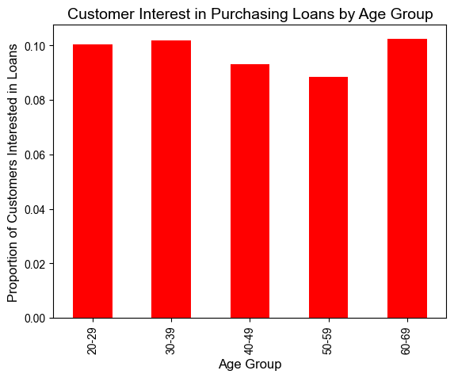

```python
# Create age bins.
bins = [20, 30, 40, 50, 60, 70]
labels = ['20-29', '30-39', '40-49', '50-59', '60-69']
personal_loan_df['AgeGroup'] = pd.cut(personal_loan_df['Age'], bins=bins, labels=labels, right=False)

# Calculate the proportion of customers interested in loans for each age group.
loan_interest_by_age = personal_loan_df.groupby('AgeGroup')['Personal_Loan'].mean()

# Print proportion of customers interested in loans by age group.
print("Loan Interest by Age Group")
print("-" * 60)
for age_group, proportion in loan_interest_by_age.items():
    print(f"Age Group: {age_group}, Proportion: {proportion}")

# Visualize results.
loan_interest_by_age.plot(kind='bar', color='red')
plt.xlabel('Age Group')
plt.ylabel('Proportion of Customers Interested in Loans')
plt.title('Customer Interest in Purchasing Loans by Age Group')
plt.show()
```

**Observations**

- There is no significant interest difference between age groups that are interested in a personal loan.
  - Customers broken down into age groups and their interest in loans:
    - Age Group 20-29: ~10.04%
    - Age Group 30-39: ~10.18%
    - Age Group 40-49: ~9.31%
    - Age Group 50-59: ~8.85%
    - Age Group 60-69: ~10.24%

#### **Question 5.** How does a customer's interest in purchasing a loan vary with their education?

```
Loan Interest by Education Level
------------------------------------------------------------
Education Level: 1, Proportion: 0.044370229007633585
Education Level: 2, Proportion: 0.12972202423378476
Education Level: 3, Proportion: 0.13657561625582945
```

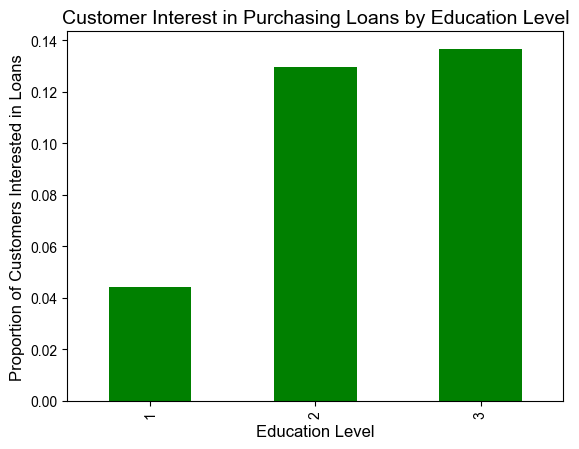

```python
# Calculate the proportion of customers interested in loans for each education level.
loan_interest_by_education = personal_loan_df.groupby('Education')['Personal_Loan'].mean()

# Print proportion of customers interested in loans by education level.
# 1: Undergrad; 2: Graduate; 3: Advanced/Professional
print("Loan Interest by Education Level")
print("-" * 60)
for education_level, proportion in loan_interest_by_education.items():
    print(f"Education Level: {education_level}, Proportion: {proportion}")

# Visualize results.
loan_interest_by_education.plot(kind='bar', color='green')
plt.xlabel('Education Level')
plt.ylabel('Proportion of Customers Interested in Loans')
plt.title('Customer Interest in Purchasing Loans by Education Level')
plt.show()
```

**Observations**

- Undergraduates at 4.44% is a very low percentrage interested in loans. This could be related to those individuals have student debt and not interested in credit card expenses or high APR. **Recommendation:** A special program with a low APR or a no interest rate penalty for a time period could interest this individuals.
- Both Graduates (12.97%) and Advanced/Professionals (13.66%) are more interested in personal loans. This could be related to greater financial stability and money management experience.

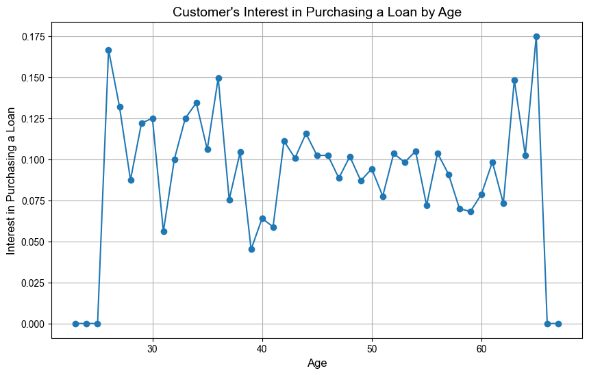

```python
# Group by age and calculate the mean interest in purchasing a loan.
age_interest_df = personal_loan_df.groupby('Age')['Personal_Loan'].mean().reset_index()

# Plot the results
plt.figure(figsize=(10, 6))
plt.plot(age_interest_df['Age'], age_interest_df['Personal_Loan'], marker='o')

# Add labels and title.
plt.title("Customer's Interest in Purchasing a Loan by Age")
plt.xlabel('Age')
plt.ylabel('Interest in Purchasing a Loan')
plt.grid(True)
plt.show()
```

#### **Question 6.** What is the distribution of mortgages for customers with and without credit cards?

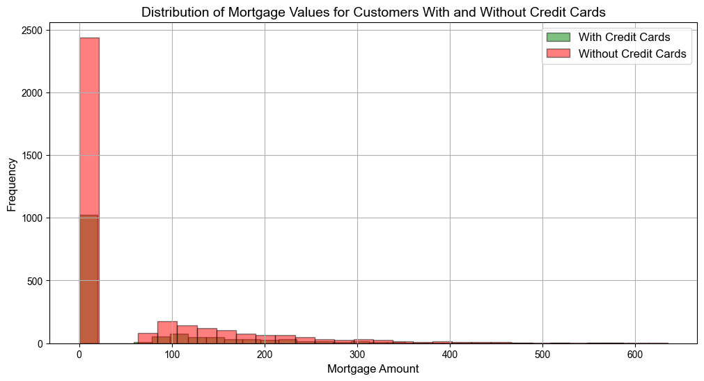

```python
# Filter the dataframe for customers with and without credit cards.
with_credit_cards = personal_loan_df[personal_loan_df['CreditCard'] == 1]
without_credit_cards = personal_loan_df[personal_loan_df['CreditCard'] == 0]

# Plot the distribution of mortgage values for customers with and without credit cards.
plt.figure(figsize=(12, 6))

# Overlay the histograms for customers with and without credit cards.
plt.hist(with_credit_cards['Mortgage'], bins=30, alpha=0.5, label='With Credit Cards', edgecolor='k',color='green')
plt.hist(without_credit_cards['Mortgage'], bins=30, alpha=0.5, label='Without Credit Cards', edgecolor='k', color='red')

# Add labels and title.
plt.title('Distribution of Mortgage Values for Customers With and Without Credit Cards')
plt.xlabel('Mortgage Amount')
plt.ylabel('Frequency')
plt.legend()
plt.grid(True)
plt.show()
```

**Observations**

#### **Question 7.** Does average spending on credit cards per month impact mortgage amount?

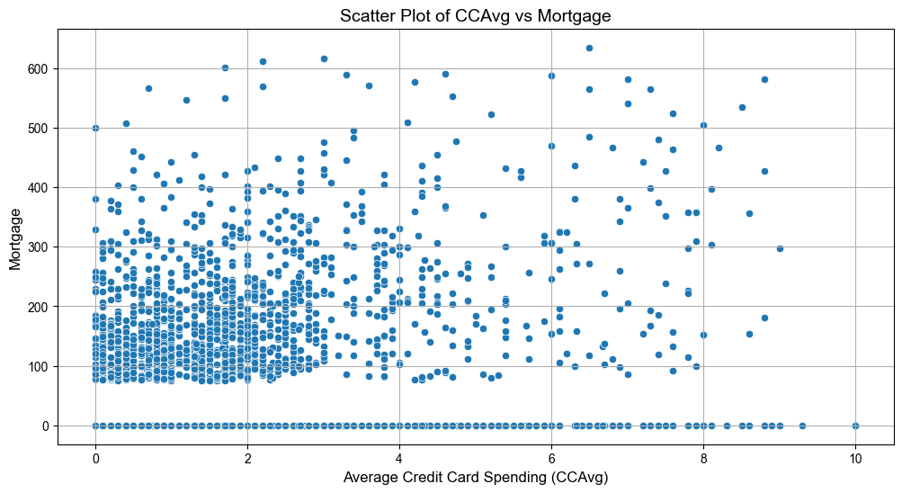

```python
# Create scatter plot of CCAvg vs Mortgage to identify any patterns.
plt.figure(figsize=(12, 6))
sns.scatterplot(x='CCAvg', y='Mortgage', data=personal_loan_df)
plt.title('Scatter Plot of CCAvg vs Mortgage')
plt.xlabel('Average Credit Card Spending (CCAvg)')
plt.ylabel('Mortgage')
plt.grid(True)
plt.show()
```

**Observations**

- The majority of data points cluster in the lower left corner, indicating that lower average credit card spending is associated with lower mortgage values.
- There are less data points as average credit card spending increases, suggesting higher credit card spending doesn’t necessarily correlate with higher mortgages.

#### **Question 8.** Does income impact mortgage amount?

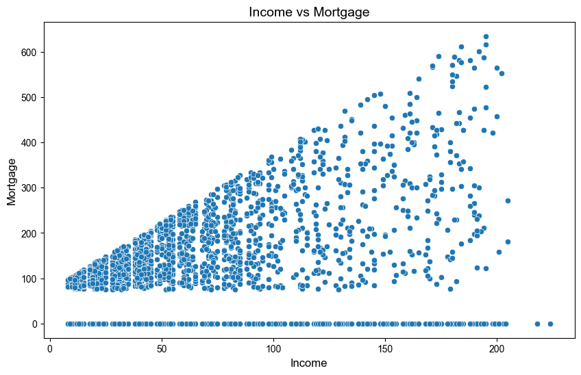

```python
# Create a scatter plot showinbg the relationship between income and mortgage.
plt.figure(figsize=(10, 6))
sns.scatterplot(x='Income', y='Mortgage', data=personal_loan_df)

# Add titles and labels.
plt.title('Income vs Mortgage')
plt.xlabel('Income')
plt.ylabel('Mortgage')

# Show the plot.
plt.show()
```

#### **Question 9.** Does income reflect higher or lower average credit card spending?

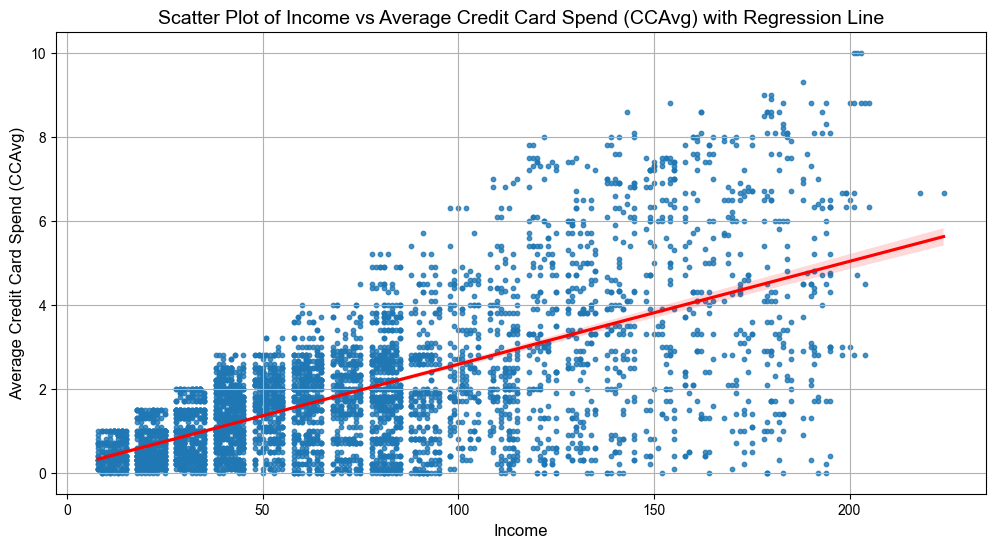

```python
# Scatter plot of Income vs CCAvg with regression line.
plt.figure(figsize=(12, 6))
sns.regplot(x='Income', y='CCAvg', data=personal_loan_df, scatter_kws={'s':10}, line_kws={'color':'red'})
plt.title('Scatter Plot of Income vs Average Credit Card Spend (CCAvg) with Regression Line')
plt.xlabel('Income')
plt.ylabel('Average Credit Card Spend (CCAvg)')
plt.grid(True)
plt.show()
```

**Observations**

#### **Question 10.** What are all of the distributions?

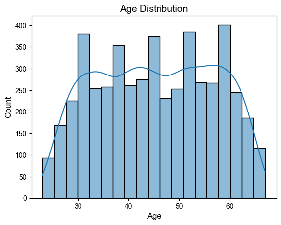

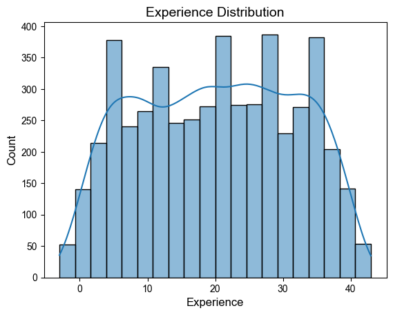

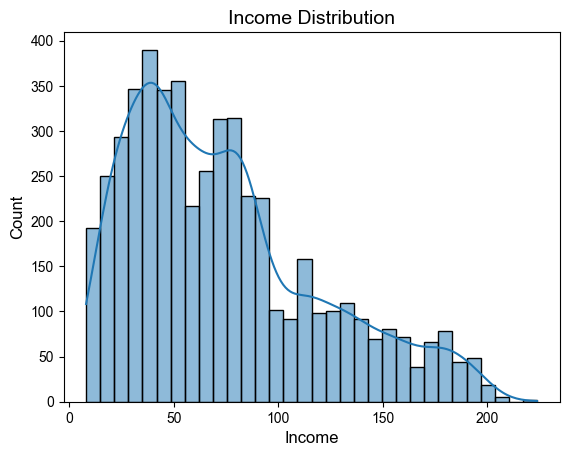

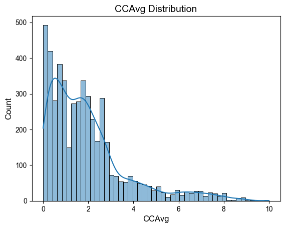

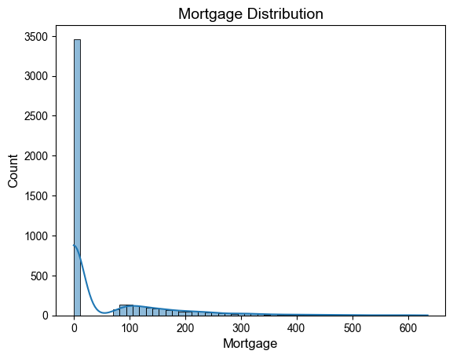

```python
# Distributions

# Age.
sns.histplot(personal_loan_df['Age'], kde=True)
plt.title('Age Distribution')
plt.show()

# Experience.
sns.histplot(personal_loan_df['Experience'], kde=True)
plt.title('Experience Distribution')
plt.show()

# Income.
sns.histplot(personal_loan_df['Income'], kde=True)
plt.title('Income Distribution')
plt.show()

# CCAvg.
sns.histplot(personal_loan_df['CCAvg'], kde=True)
plt.title('CCAvg Distribution')
plt.show()

# Mortgage.
sns.histplot(personal_loan_df['Mortgage'], kde=True)
plt.title('Mortgage Distribution')
plt.show()
```

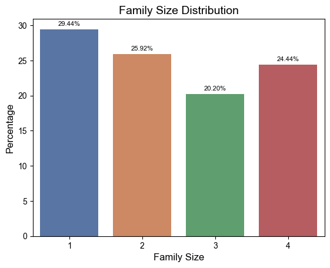

```python
# Calculate the percentage of each family size.
family_counts = personal_loan_df['Family'].value_counts(normalize=True) * 100

# Ensure the values are in order
family_counts = family_counts.sort_index()

# Create the barplot.
sns.barplot(x=family_counts.index, y=family_counts.values, palette="deep")
plt.title('Family Size Distribution')
plt.xlabel('Family Size')
plt.ylabel('Percentage')

# Add percentages on top of the bars.
for index, value in enumerate(family_counts.values):
    plt.text(index, value + 0.5, f'{value:.2f}%', ha='center')

plt.show()
```

[figure not shown]

```python
# Calculate the percentage of education levels.
edu_counts = personal_loan_df['Education'].value_counts(normalize=True) * 100

# Ensure the values are in order.
edu_counts = edu_counts.sort_index()

# Create the barplot.
sns.barplot(x=family_counts.index, y=family_counts.values, palette='viridis')
plt.title('Education Distribution')
plt.xlabel('Education Levels')
plt.ylabel('Percentage')

# Add percentages on top of the bars.
for index, value in enumerate(edu_counts.values):
    plt.text(index, value + 0.5, f'{value:.2f}%', ha='center')

plt.show()
```

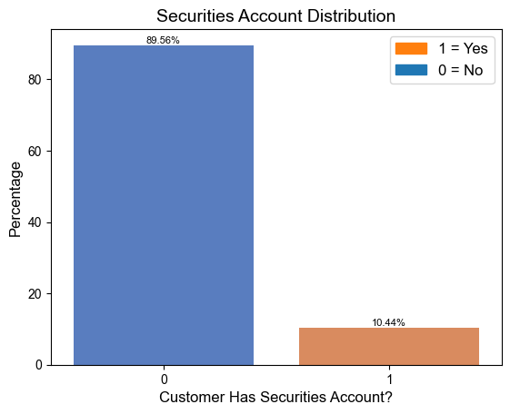

```python
# Calculate the percentage of securities accounts.
sec_accts_counts = personal_loan_df['Securities_Account'].value_counts(normalize=True) * 100

# Ensure the values are in order.
sec_accts_counts = sec_accts_counts.sort_index()

# Create the barplot.
sns.barplot(x=sec_accts_counts.index, y=sec_accts_counts.values, palette='muted')
plt.title('Securities Account Distribution')
plt.xlabel('Customer Has Securities Account?')
plt.ylabel('Percentage')

# Add percentages on top of the bars.
for index, value in enumerate(sec_accts_counts.values):
    plt.text(index, value + 0.5, f'{value:.2f}%', ha='center')

# Create a legend.
no_patch = mpatches.Patch(color='C0', label='0 = No')
yes_patch = mpatches.Patch(color='C1', label='1 = Yes')

plt.legend(handles=[yes_patch, no_patch])
plt.show()
```

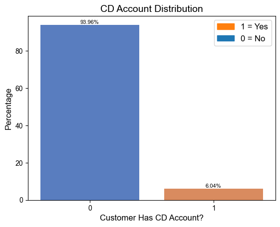

```python
# Calculate the percentage of securities accounts.
cd_accts_counts = personal_loan_df['CD_Account'].value_counts(normalize=True) * 100

# Ensure the values are in order.
cd_accts_counts = cd_accts_counts.sort_index()

# Create the barplot.
sns.barplot(x=cd_accts_counts.index, y=cd_accts_counts.values, palette='muted')
plt.title('CD Account Distribution')
plt.xlabel('Customer Has CD Account?')
plt.ylabel('Percentage')

# Add percentages on top of the bars.
for index, value in enumerate(cd_accts_counts.values):
    plt.text(index, value + 0.5, f'{value:.2f}%', ha='center')

# Create a legend.
no_patch = mpatches.Patch(color='C0', label='0 = No')
yes_patch = mpatches.Patch(color='C1', label='1 = Yes')

plt.legend(handles=[yes_patch, no_patch])
plt.show()
```

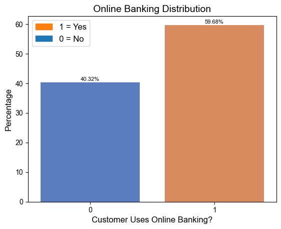

```python
# Calculate the percentage of online users.
online_user_counts = personal_loan_df['Online'].value_counts(normalize=True) * 100

# Ensure the values are in order.
online_user_counts = online_user_counts.sort_index()

# Create the barplot.
sns.barplot(x=online_user_counts.index, y=online_user_counts.values, palette='muted')
plt.title('Online Banking Distribution')
plt.xlabel('Customer Uses Online Banking?')
plt.ylabel('Percentage')

# Add percentages on top of the bars.
for index, value in enumerate(online_user_counts.values):
    plt.text(index, value + 0.5, f'{value:.2f}%', ha='center')

# Create a legend.
no_patch = mpatches.Patch(color='C0', label='0 = No')
yes_patch = mpatches.Patch(color='C1', label='1 = Yes')

plt.legend(handles=[yes_patch, no_patch])
plt.show()
```

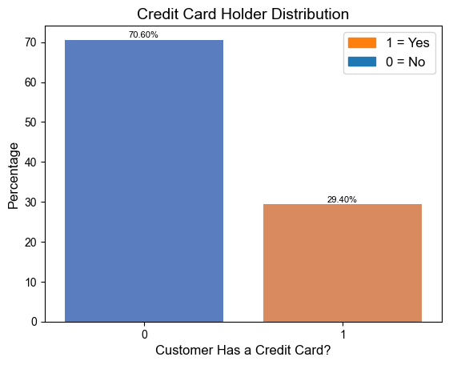

```python
# Calculate the percentage of online users.
cc_holder_counts = personal_loan_df['CreditCard'].value_counts(normalize=True) * 100

# Ensure the values are in order.
cc_holder_counts = cc_holder_counts.sort_index()

# Create the barplot.
sns.barplot(x=cc_holder_counts.index, y=cc_holder_counts.values, palette='muted')
plt.title('Credit Card Holder Distribution')
plt.xlabel('Customer Has a Credit Card?')
plt.ylabel('Percentage')

# Add percentages on top of the bars.
for index, value in enumerate(cc_holder_counts.values):
    plt.text(index, value + 0.5, f'{value:.2f}%', ha='center')

# Create a legend.
no_patch = mpatches.Patch(color='C0', label='0 = No')
yes_patch = mpatches.Patch(color='C1', label='1 = Yes')

plt.legend(handles=[yes_patch, no_patch])
plt.show()
```

```python
# Calculate the total counts of each ZIP code.
zipcode_counts = personal_loan_df['ZIPCode'].value_counts()

# Calculate the percentage for each ZIP code.
zipcode_percentages = (zipcode_counts / zipcode_counts.sum()) * 100

# Select the top 50 ZIP codes.
top_50_zipcodes = zipcode_counts.head(50)
top_50_percentages = zipcode_percentages.head(50)

# Convert the result to a DataFrame.
top_50_zipcode_df = pd.DataFrame({
    'ZIPCode': top_50_zipcodes.index,
    'Count': top_50_zipcodes.values,
    'Percentage': top_50_percentages.values
})

# Format the 'Percentage' column to two decimal places.
top_50_zipcode_df['Percentage'] = top_50_zipcode_df['Percentage'].map('{:.2f}%'.format)

# Display the DataFrame as a table.
print(top_50_zipcode_df)
```

```
    ZIPCode  Count Percentage
0     94720    169      3.38%
1     94305    127      2.54%
2     95616    116      2.32%
3     90095     71      1.42%
4     93106     57      1.14%
5     93943     54      1.08%
6     92037     54      1.08%
7     91320     53      1.06%
8     91711     52      1.04%
9     94025     52      1.04%
10    92093     51      1.02%
11    90024     50      1.00%
12    90245     50      1.00%
13    90089     46      0.92%
```

[output cut: 36 more lines]

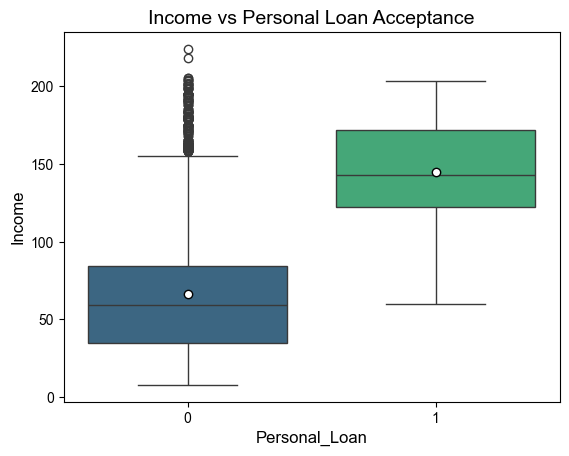

```python
# Income vs Personal Loan Acceptance.
sns.boxplot(x='Personal_Loan', y='Income', data=personal_loan_df, palette='viridis', showmeans=True, meanprops={"marker":"o","markerfacecolor":"white", "markeredgecolor":"black"})
plt.title('Income vs Personal Loan Acceptance')
plt.show()
```

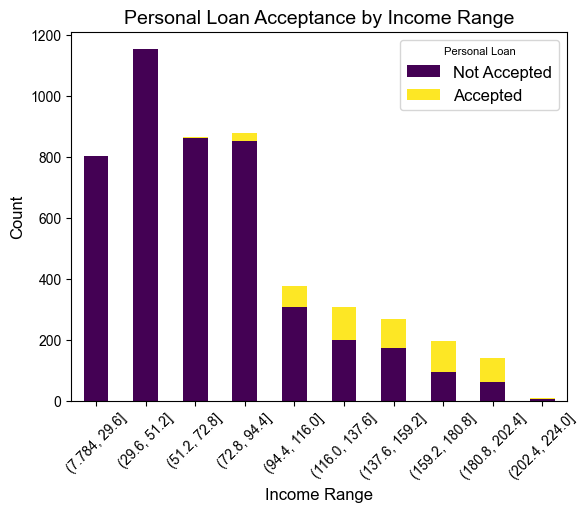

```python
# Find the number of customers who accepted and did not accept the personal loan.

# Bin the Income data into ranges.
income_bins = pd.cut(personal_loan_df['Income'], bins=10)

# Create a crosstab to count the occurrences of each Personal_Loan status within each income range.
income_loan_crosstab = pd.crosstab(income_bins, personal_loan_df['Personal_Loan'])

# Plot the stacked bar plot.
income_loan_crosstab.plot(kind='bar', stacked=True, colormap='viridis')
plt.title('Personal Loan Acceptance by Income Range')
plt.xlabel('Income Range')
plt.ylabel('Count')
plt.legend(title='Personal Loan', labels=['Not Accepted', 'Accepted'])
plt.xticks(rotation=45)
plt.show()
```

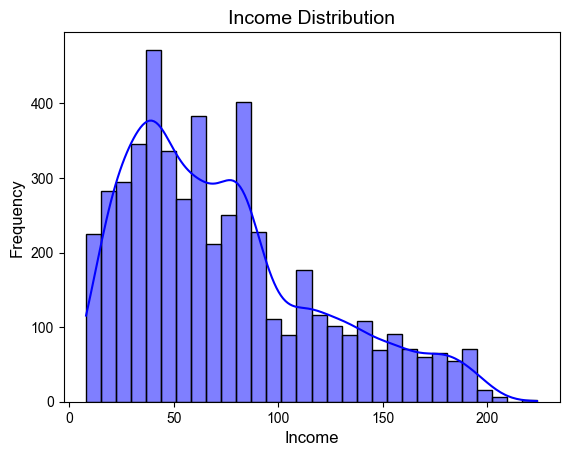

```python
# Create a histogram plot for Income.
sns.histplot(data=personal_loan_df, x='Income', kde=True, bins=30, color='blue')
plt.title('Income Distribution')
plt.xlabel('Income')
plt.ylabel('Frequency')
plt.show()
```

#### **Question 11.** What is the relationship between Online Banking Usage vs Education?

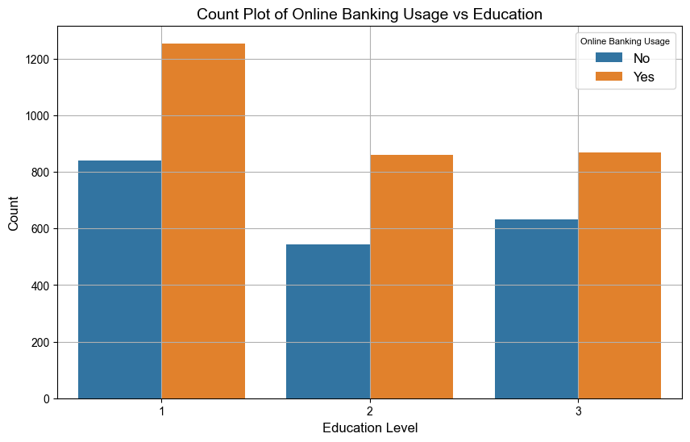

```python
# Create a count plot to visualize the relationship between Online and Education.
plt.figure(figsize=(10, 6))
sns.countplot(x='Education', hue='Online', data=personal_loan_df)
plt.title('Count Plot of Online Banking Usage vs Education')
plt.xlabel('Education Level')
plt.ylabel('Count')
plt.legend(title='Online Banking Usage', loc='upper right', labels=['No', 'Yes'])
plt.grid(True)
plt.show()
```

**Observations**

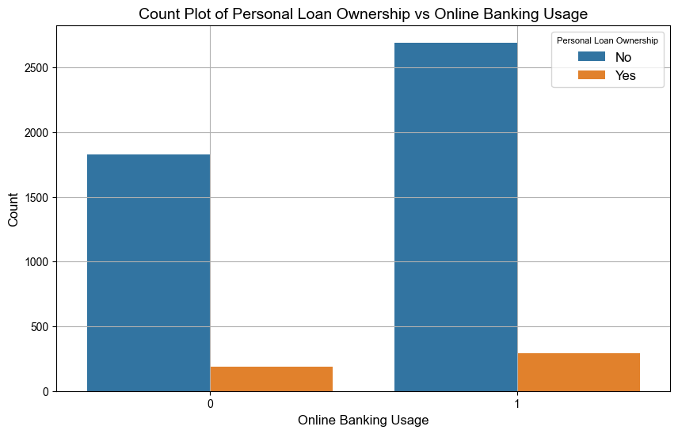

```python
# Create a count plot to visualize the relationship between Online Banking and Personal Loan.
plt.figure(figsize=(10, 6))
sns.countplot(x='Online', hue='Personal_Loan', data=personal_loan_df)
plt.title('Count Plot of Personal Loan Ownership vs Online Banking Usage')
plt.xlabel('Online Banking Usage')
plt.ylabel('Count')
plt.legend(title='Personal Loan Ownership', loc='upper right', labels=['No', 'Yes'])
plt.grid(True)
plt.show()
```

**Observations**

- There is no relationship between online banking use and owning a personal loan.

#### **Question 13.** What is the relationship between Online Banking Usage vs Top 10 ZIP Codes?

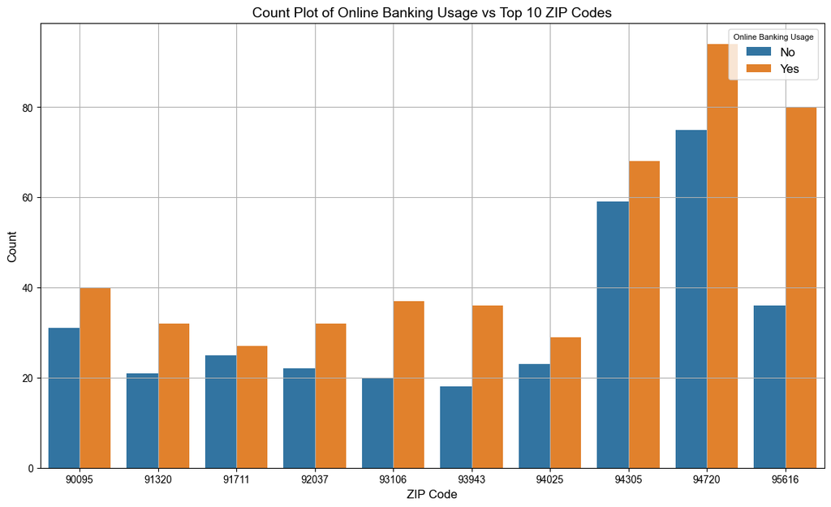

```python
# Get the top 10 ZIP codes by count.
top_10_zip_codes = personal_loan_df['ZIPCode'].value_counts().nlargest(10).index

# Filter the dataframe to include only the top 10 ZIP codes.
top_10_df = personal_loan_df[personal_loan_df['ZIPCode'].isin(top_10_zip_codes)]

# Create a count plot to visualize the relationship between Online and the top 10 ZIP codes.
plt.figure(figsize=(14, 8))
sns.countplot(x='ZIPCode', hue='Online', data=top_10_df)
plt.title('Count Plot of Online Banking Usage vs Top 10 ZIP Codes')
plt.xlabel('ZIP Code')
plt.ylabel('Count')
plt.legend(title='Online Banking Usage', loc='upper right', labels=['No', 'Yes'])
plt.grid(True)
plt.show()
```

**Observations**

- There are three zipcodes, 94720, 95616 and 94305, who are the largest users of online banking. These zipcodes could indicate more affluent areas with higher education levels that are comfortable using online banking.

#### **Question 14.** What is the relationship between having a CD Account vs Education?

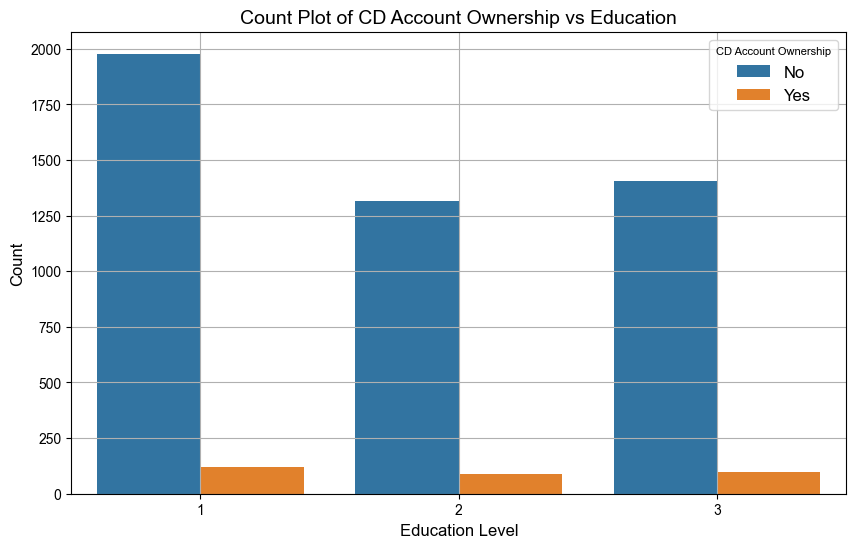

```python
# Create a count plot to visualize the relationship between CD_Account and Education.
plt.figure(figsize=(10, 6))
sns.countplot(x='Education', hue='CD_Account', data=personal_loan_df)
plt.title('Count Plot of CD Account Ownership vs Education')
plt.xlabel('Education Level')
plt.ylabel('Count')
plt.legend(title='CD Account Ownership', loc='upper right', labels=['No', 'Yes'])
plt.grid(True)
plt.show()
```

**Observations**

- There is no relationship between customers that own a CD Account vs their level of education.

#### **Question 15.** What is the relationship between having a Average Credit Card spending vs Education?

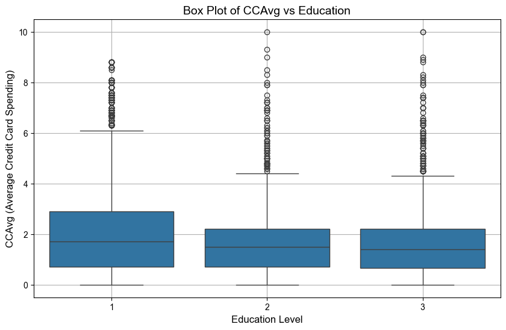

```python
# Create a box plot to visualize the relationship between CCAvg and Education.
plt.figure(figsize=(10, 6))
sns.boxplot(x='Education', y='CCAvg', data=personal_loan_df)
plt.title('Box Plot of CCAvg vs Education')
plt.xlabel('Education Level')
plt.ylabel('CCAvg (Average Credit Card Spending)')
plt.grid(True)
plt.show()
```

**Observations**

#### **Question 16.** What is the relationship between having a Average Credit Card spending vs Mortgage?

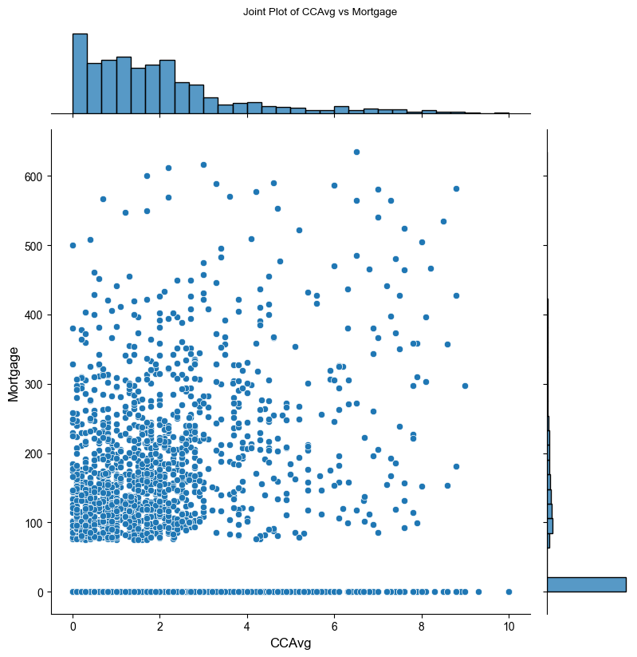

```python
# Create a joint plot to visualize the relationship between CCAvg and Mortgage.
sns.jointplot(x='CCAvg', y='Mortgage', data=personal_loan_df, kind='scatter', height=8, marginal_kws=dict(bins=30, fill=True))
plt.suptitle('Joint Plot of CCAvg vs Mortgage', y=1.02)
plt.show()
```

**Observations**

- The lower average credit card spending is associated with lower mortgage values, as indicated by the dense cluster of data points at the origin.
- As ‘CCAvg’ increases, there is more spread in the ‘Mortgage’ values, but no clear upward or downward trend is visible.
- Customers with lower credit card spending tend to have lower mortgage amounts.
- There is no straightforward linear relationship between credit card spending and mortgage values.